# Estimate nu via Kurtosis

# Replace the mean of $\hat{\text{kurt}}$ by median value

### Compare estimation performance with $T$ changes

```r
N <- 10
res <- list()
for (i in 1:length(T_pool)) {
  T <- T_pool[i]
  # print(T)
  res[[i]] <- sapply(1:repeate, function(idx) {est_nu_kurtosis(genX(N = N, T = T), comb_fun = median)})
}

sapply(res, median)
```

```
##  [1] 13.93589 14.60776 14.65949 15.62597 14.70648 15.33774 16.22680
##  [8] 15.59850 15.99859 15.72357 15.85797
```

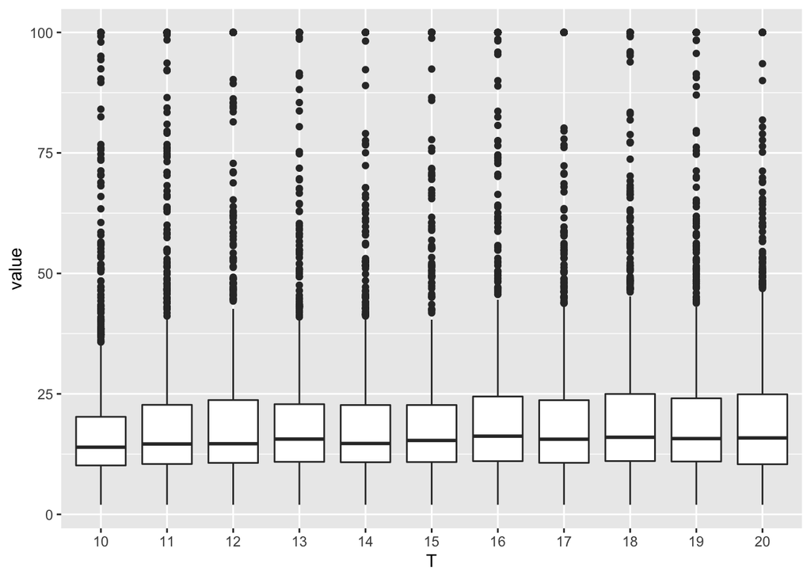

```r
library(ggplot2)
data <- reshape2::melt(data.frame("T" = T_pool, do.call(rbind, res)), id.vars = "T")
data$T <- as.factor(data$T)
ggplot(data, aes(x = T, y = value)) + geom_boxplot()
```

```r
# ggplot(data, aes(x = T, y = value)) + geom_violin()
```

### Compare estimation performance with $\nu$ changes

```r
N <- 10
T <- 15
res <- list()
for (i in 1:length(nu_pool)) {
  nu <- nu_pool[i]
  # print(nu)
  res[[i]] <- sapply(1:repeate, function(idx) {est_nu_kurtosis(genX(N = N, T = T, nu = nu), comb_fun = median)})
}

sapply(res, median)
```

```
##  [1] 11.06786 13.75916 15.38473 15.93740 17.03207 17.21321 17.89016
##  [8] 17.77739 17.44181 18.82367 17.09315 17.86509 18.02965 17.74435
## [15] 18.19585 17.95827 17.76729 18.46321
```

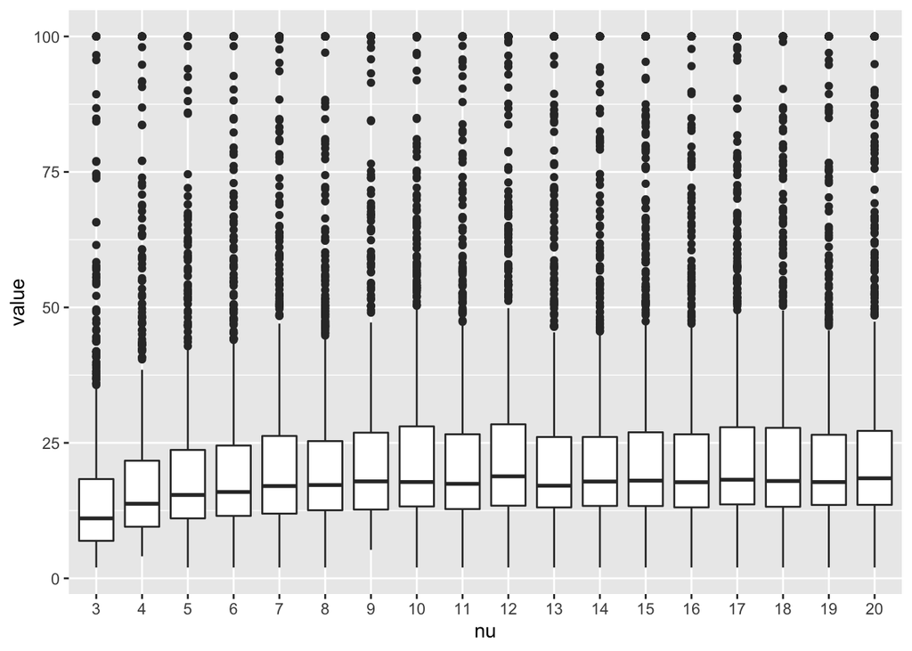

```r
library(ggplot2)
data <- reshape2::melt(data.frame("nu" = nu_pool, do.call(rbind, res)), id.vars = "nu")
data$nu <- as.factor(data$nu)
ggplot(data, aes(x = nu, y = value)) + geom_boxplot()
```

```r
# ggplot(data, aes(x = nu, y = value)) + geom_violin()
```

Well, it seems that using median value is worse than using the simple mean value.

# Try with large $N$

```r
N <- 100
T_pool <- seq(10, 200, 10)
res <- list()
for (i in 1:length(T_pool)) {
  T <- T_pool[i]
  # print(T)
  res[[i]] <- sapply(1:repeate, function(idx) {est_nu_kurtosis(genX(N = N, T = T))})
}

sapply(res, median)
```

```
##  [1] 7.996191 6.067808 5.402352 5.098427 5.008098 4.861782 4.822098
##  [8] 4.704335 4.672151 4.640775 4.633144 4.648922 4.550165 4.554223
## [15] 4.534813 4.494691 4.512233 4.502476 4.490656 4.483394
```

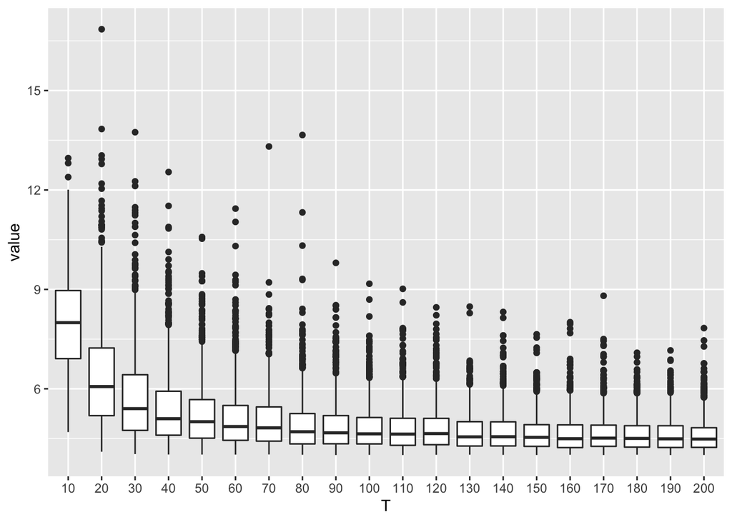

```r
library(ggplot2)
data <- reshape2::melt(data.frame("T" = T_pool, do.call(rbind, res)), id.vars = "T")
data$T <- as.factor(data$T)
ggplot(data, aes(x = T, y = value)) + geom_boxplot()
```

```r
# ggplot(data, aes(x = T, y = value)) + geom_violin()
```

It seems with large $N$, the etimators via kurtosis becomes really good.

# Compare estimation performance with $N$ changes

Now we fix the ratio $T/N$ be $1.1$ and change $N$ from $10$ to $100$ to see the results

```r
N_pool <- seq(10, 100, 10)
res <- list()
for (i in 1:length(N_pool)) {
  N <- N_pool[i]
  # print(T)
  res[[i]] <- sapply(1:repeate, function(idx) {est_nu_kurtosis(genX(N = N, T = round(N*1.1)))})
}

sapply(res, median)
```

```
##  [1] 8.441350 6.013148 5.393267 5.167962 4.995618 4.815071 4.765980
##  [8] 4.661051 4.659756 4.646878
```

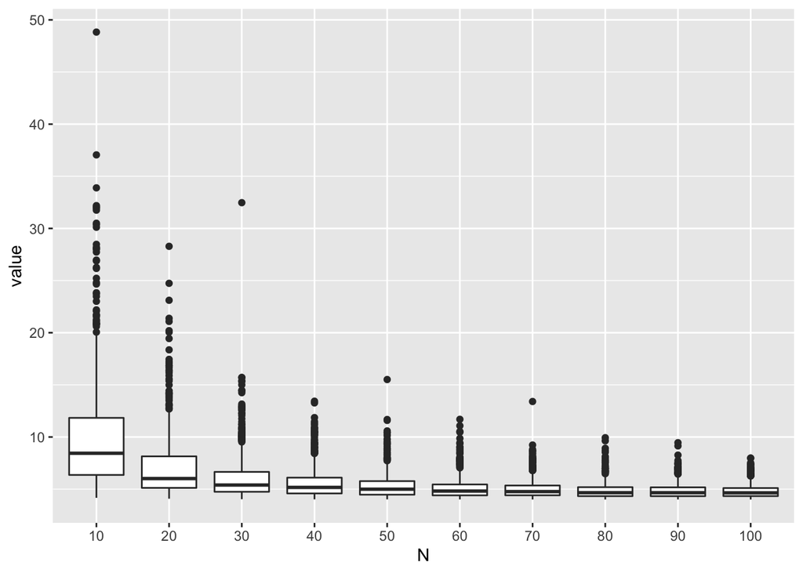

```r
library(ggplot2)
data <- reshape2::melt(data.frame("N" = N_pool, do.call(rbind, res)), id.vars = "N")
data$N <- as.factor(data$N)
ggplot(data, aes(x = N, y = value)) + geom_boxplot()
```

```r
# ggplot(data, aes(x = T, y = value)) + geom_violin()
```

It is clear that when $N$ increase, the estimation performance also improves. An explanation for that could be: the simple average of $\hat{\text{kurt}}$ become more reliable when $N$ goes large.